# CS 464

```python
# CNN  (PARAMETER EXTRA TRIAL 4 FOR CNN)(BATCHSIZE:44, LR:5e-2)
max_epoch = 14
train_batch = 44
test_batch = 44
learning_rate = 5e-2
momentum = 0.5
weight_decay = 5e-04

model_CNN = ConvNet()
criterion = nn.CrossEntropyLoss()
optimizer = torch.optim.SGD(model_CNN.parameters(), lr=learning_rate, weight_decay=5e-04) # you can play with weight_decay as well but do not add additional parameters

PATH_CNN_SGD = "/content/drive/MyDrive/CS464_HW3/best_cnn_sgd.pth"
min_vald_loss = np.inf
history = {'train_accuracy': [], 'vald_accuracy':[], 'train_loss': [], 'vald_loss': []}

for epoch in range(max_epoch):
    train_loss = 0.0
    train_correct = 0
    for i, data in enumerate(train_loader, 0):
        inputs, labels = data
        optimizer.zero_grad()
        input = inputs.permute(0, 3, 1, 2)
        outputs = model_CNN(input.float())
        preds = torch.argmax(outputs, dim=1)
        train_correct += torch.sum(preds==labels)
        loss = criterion(outputs, labels)
        loss.backward()
        optimizer.step()
        train_loss += loss.item()

    with torch.no_grad():
        vald_loss = 0.0
        vald_correct = 0
        for data in validation_loader:
            images, labels = data
            images = images.permute(0, 3, 1, 2)
            outputs = model_CNN(images.float())
            preds = torch.argmax(outputs, dim=1)
            vald_correct += torch.sum(preds==labels)
            loss = criterion(outputs, labels)
            vald_loss += loss.item()

    print(f'Epoch {epoch+1}:\t\t train_loss: {(train_loss / len(train_loader)):.2f}\t\t train_accuracy: {(train_correct / (len(train_loader) * train_batch)):.2f}\t\t validation_loss: {(vald_loss / len(validation_loader)):.2f}\t\t validation_accuracy: {(vald_correct / (len(validation_loader) * test_batch)):.2f}')
    if (vald_loss / len(validation_loader)) < min_vald_loss:
        print(f'Saving new best CNN SGD with vald_loss: {(vald_loss / len(validation_loader)):.2f}')
        min_vald_loss = (vald_loss / len(validation_loader))
        torch.save(model_CNN.state_dict(), PATH_CNN_SGD)

    history['train_loss'].append(train_loss / len(train_loader))
    history['vald_loss'].append(vald_loss / len(validation_loader))
    history['train_accuracy'].append(train_correct / (len(train_loader) * train_batch))
    history['vald_accuracy'].append(vald_correct / (len(validation_loader) * test_batch))

print(f'Best validation loss: {min_vald_loss}')
```

```
Epoch 1:		 train_loss: 1.35		 train_accuracy: 0.46		 validation_loss: 1.26		 validation_accuracy: 0.70
Saving new best CNN SGD with vald_loss: 1.26
Epoch 2:		 train_loss: 1.28		 train_accuracy: 0.61		 validation_loss: 1.20		 validation_accuracy: 0.67
Saving new best CNN SGD with vald_loss: 1.20
Epoch 3:		 train_loss: 1.18		 train_accuracy: 0.77		 validation_loss: 1.21		 validation_accuracy: 0.67
Epoch 4:		 train_loss: 1.13		 train_accuracy: 0.85		 validation_loss: 1.21		 validation_accuracy: 0.66
Epoch 5:		 train_loss: 1.11		 train_accuracy: 0.86		 validation_loss: 1.19		 validation_accuracy: 0.68
Saving new best CNN SGD with vald_loss: 1.19
Epoch 6:		 train_loss: 1.03		 train_accuracy: 0.98		 validation_loss: 1.15		 validation_accuracy: 0.74
Saving new best CNN SGD with vald_loss: 1.15
Epoch 7:		 train_loss: 1.01		 train_accuracy: 1.02		 validation_loss: 1.06		 validation_accuracy: 0.83
Saving new best CNN SGD with vald_loss: 1.06
Epoch 8:		 train_loss: 0.98		 train_accuracy: 1.04		 validation_loss: 1.02		 validation_accuracy: 0.92
Saving new best CNN SGD with vald_loss: 1.02
Epoch 9:		 train_loss: 0.94		 train_accuracy: 1.10		 validation_loss: 0.97		 validation_accuracy: 0.99
Saving new best CNN SGD with vald_loss: 0.97
Epoch 10:		 train_loss: 0.99		 train_accuracy: 1.01		 validation_loss: 0.90		 validation_accuracy: 1.08
Saving new best CNN SGD with vald_loss: 0.90
Epoch 11:		 train_loss: 0.93		 train_accuracy: 1.10		 validation_loss: 1.09		 validation_accuracy: 0.81
Epoch 12:		 train_loss: 0.95		 train_accuracy: 1.10		 validation_loss: 1.01		 validation_accuracy: 0.94
Epoch 13:		 train_loss: 0.92		 train_accuracy: 1.13		 validation_loss: 0.97		 validation_accuracy: 1.00
Epoch 14:		 train_loss: 0.91		 train_accuracy: 1.13		 validation_loss: 0.88		 validation_accuracy: 1.11
Saving new best CNN SGD with vald_loss: 0.88
Best validation loss: 0.8759017586708069
```

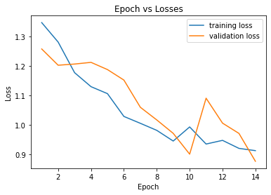

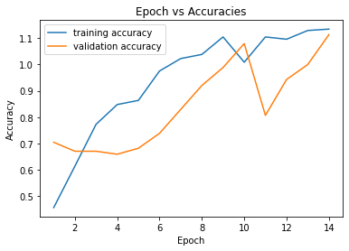

```python
# CNN  (PARAMETER EXTRA TRIAL 4 FOR CNN)(BATCHSIZE:44, LR:5e-2)
# plot losses vs epoch
plt.plot([i+1 for i in range(max_epoch)], history['train_loss'], label='training loss')
plt.plot([i+1 for i in range(max_epoch)], history['vald_loss'], label='validation loss')
plt.xlabel('Epoch')
plt.ylabel('Loss')
plt.title('Epoch vs Losses')
plt.legend(loc='upper right')
plt.show()

# plot accuracies vs epoch
plt.plot([i+1 for i in range(max_epoch)], history['train_accuracy'], label='training accuracy')
plt.plot([i+1 for i in range(max_epoch)], history['vald_accuracy'], label='validation accuracy')
plt.xlabel('Epoch')
plt.ylabel('Accuracy')
plt.title('Epoch vs Accuracies')
plt.legend(loc='upper left')
plt.show()
```

```
Macro Precision: 0.7950687945123565 Macro Recall: 0.7772663413191364 Macro F1: 0.7768405259299982
Accuracy 0.8044444444444444
Accuracies for each class:
	Accuracy for Cloudy           0.5961538461538461
	Accuracy for Rain             0.5869565217391305
	Accuracy for Shine            0.9387755102040817
	Accuracy for Sunrise          0.9871794871794872
```

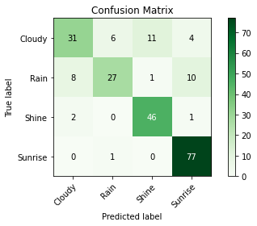

```python
# CNN  (PARAMETER EXTRA TRIAL 4 FOR CNN)(BATCHSIZE:44, LR:5e-2)
model_cnn = ConvNet()
model_cnn.load_state_dict(torch.load(PATH_CNN_SGD))

# evaluate on test set
# model = model.eval()

predictions = []

with torch.no_grad():
#   iterate over test batches
    for data in test_loader:
        images, labels = data
        images = images.permute(0, 3, 1, 2)
        #images, labels = images.cuda(), labels.cuda()
        outputs = model_cnn(images.float())
        _, predicted2 = torch.max(outputs.data, 1)
        predictions.extend(predicted2.tolist())

#   get confusion matrix
#   calculate accuracy
#   calculate precision
#   calculate recall
#   calculate F1 score
labelAndNames = {0: "Cloudy", 1: "Rain", 2: "Shine", 3: "Sunrise"}
cm = confusion_matrix(y_test,predictions)
# plot confusion matrix
plot_cm(cm, labelAndNames.values())
pscore = precision_score(y_test, predictions, average="macro")
rscore = recall_score(y_test, predictions, average="macro")
f1 = f1_score(y_test, predictions, average="macro")
print("Macro Precision:", pscore, "Macro Recall:", rscore,"Macro F1:" ,f1)
print("Accuracy", accuracy_score(y_test,predictions))
acc_per_class = cm.diagonal()/cm.sum(1)
print("Accuracies for each class:")
for i, acc in enumerate(acc_per_class):
    print(f'\tAccuracy for {labelAndNames[i]}'.ljust(30, ' '), acc)
```

```python
# CNN  (PARAMETER EXTRA TRIAL 5 FOR CNN)(BATCHSIZE:44, LR:5e-3)
max_epoch = 14
train_batch = 44
test_batch = 44
learning_rate = 5e-3
momentum = 0.5
weight_decay = 5e-04

model_CNN = ConvNet()
criterion = nn.CrossEntropyLoss()
optimizer = torch.optim.SGD(model_CNN.parameters(), lr=learning_rate, weight_decay=5e-04) # you can play with weight_decay as well but do not add additional parameters

PATH_CNN_SGD = "/content/drive/MyDrive/CS464_HW3/best_cnn_sgd.pth"
min_vald_loss = np.inf
history = {'train_accuracy': [], 'vald_accuracy':[], 'train_loss': [], 'vald_loss': []}

for epoch in range(max_epoch):
    train_loss = 0.0
    train_correct = 0
    for i, data in enumerate(train_loader, 0):
        inputs, labels = data
        optimizer.zero_grad()
        input = inputs.permute(0, 3, 1, 2)
        outputs = model_CNN(input.float())
        preds = torch.argmax(outputs, dim=1)
        train_correct += torch.sum(preds==labels)
        loss = criterion(outputs, labels)
        loss.backward()
        optimizer.step()
        train_loss += loss.item()

    with torch.no_grad():
        vald_loss = 0.0
        vald_correct = 0
        for data in validation_loader:
            images, labels = data
            images = images.permute(0, 3, 1, 2)
            outputs = model_CNN(images.float())
            preds = torch.argmax(outputs, dim=1)
            vald_correct += torch.sum(preds==labels)
            loss = criterion(outputs, labels)
            vald_loss += loss.item()

    print(f'Epoch {epoch+1}:\t\t train_loss: {(train_loss / len(train_loader)):.2f}\t\t train_accuracy: {(train_correct / (len(train_loader) * train_batch)):.2f}\t\t validation_loss: {(vald_loss / len(validation_loader)):.2f}\t\t validation_accuracy: {(vald_correct / (len(validation_loader) * test_batch)):.2f}')
    if (vald_loss / len(validation_loader)) < min_vald_loss:
        print(f'Saving new best CNN SGD with vald_loss: {(vald_loss / len(validation_loader)):.2f}')
        min_vald_loss = (vald_loss / len(validation_loader))
        torch.save(model_CNN.state_dict(), PATH_CNN_SGD)

    history['train_loss'].append(train_loss / len(train_loader))
    history['vald_loss'].append(vald_loss / len(validation_loader))
    history['train_accuracy'].append(train_correct / (len(train_loader) * train_batch))
    history['vald_accuracy'].append(vald_correct / (len(validation_loader) * test_batch))

print(f'Best validation loss: {min_vald_loss}')
```

```
Epoch 1:		 train_loss: 1.37		 train_accuracy: 0.43		 validation_loss: 1.37		 validation_accuracy: 0.40
Saving new best CNN SGD with vald_loss: 1.37
Epoch 2:		 train_loss: 1.35		 train_accuracy: 0.43		 validation_loss: 1.33		 validation_accuracy: 0.40
Saving new best CNN SGD with vald_loss: 1.33
Epoch 3:		 train_loss: 1.31		 train_accuracy: 0.51		 validation_loss: 1.29		 validation_accuracy: 0.56
Saving new best CNN SGD with vald_loss: 1.29
Epoch 4:		 train_loss: 1.26		 train_accuracy: 0.70		 validation_loss: 1.24		 validation_accuracy: 0.70
Saving new best CNN SGD with vald_loss: 1.24
Epoch 5:		 train_loss: 1.22		 train_accuracy: 0.72		 validation_loss: 1.20		 validation_accuracy: 0.78
Saving new best CNN SGD with vald_loss: 1.20
Epoch 6:		 train_loss: 1.18		 train_accuracy: 0.80		 validation_loss: 1.18		 validation_accuracy: 0.83
Saving new best CNN SGD with vald_loss: 1.18
Epoch 7:		 train_loss: 1.16		 train_accuracy: 0.90		 validation_loss: 1.17		 validation_accuracy: 0.84
Saving new best CNN SGD with vald_loss: 1.17
Epoch 8:		 train_loss: 1.14		 train_accuracy: 0.95		 validation_loss: 1.16		 validation_accuracy: 0.85
Saving new best CNN SGD with vald_loss: 1.16
Epoch 9:		 train_loss: 1.12		 train_accuracy: 0.97		 validation_loss: 1.15		 validation_accuracy: 0.86
Saving new best CNN SGD with vald_loss: 1.15
Epoch 10:		 train_loss: 1.10		 train_accuracy: 0.99		 validation_loss: 1.14		 validation_accuracy: 0.86
Saving new best CNN SGD with vald_loss: 1.14
Epoch 11:		 train_loss: 1.09		 train_accuracy: 0.99		 validation_loss: 1.13		 validation_accuracy: 0.86
Saving new best CNN SGD with vald_loss: 1.13
Epoch 12:		 train_loss: 1.08		 train_accuracy: 1.00		 validation_loss: 1.12		 validation_accuracy: 0.86
Saving new best CNN SGD with vald_loss: 1.12
Epoch 13:		 train_loss: 1.06		 train_accuracy: 1.00		 validation_loss: 1.11		 validation_accuracy: 0.86
Saving new best CNN SGD with vald_loss: 1.11
Epoch 14:		 train_loss: 1.05		 train_accuracy: 1.01		 validation_loss: 1.11		 validation_accuracy: 0.86
Saving new best CNN SGD with vald_loss: 1.11
Best validation loss: 1.1056759357452393
```

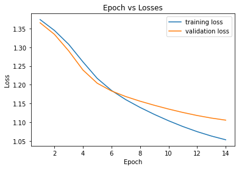

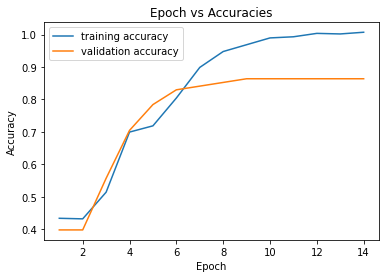

```python
# CNN  (PARAMETER EXTRA TRIAL 5 FOR CNN)(BATCHSIZE:44, LR:5e-3)
# plot losses vs epoch
plt.plot([i+1 for i in range(max_epoch)], history['train_loss'], label='training loss')
plt.plot([i+1 for i in range(max_epoch)], history['vald_loss'], label='validation loss')
plt.xlabel('Epoch')
plt.ylabel('Loss')
plt.title('Epoch vs Losses')
plt.legend(loc='upper right')
plt.show()

# plot accuracies vs epoch
plt.plot([i+1 for i in range(max_epoch)], history['train_accuracy'], label='training accuracy')
plt.plot([i+1 for i in range(max_epoch)], history['vald_accuracy'], label='validation accuracy')
plt.xlabel('Epoch')
plt.ylabel('Accuracy')
plt.title('Epoch vs Accuracies')
plt.legend(loc='upper left')
plt.show()
```

```python
# CNN  (PARAMETER EXTRA TRIAL 4 FOR CNN)(BATCHSIZE:44, LR:5e-2)
model_cnn = ConvNet()
model_cnn.load_state_dict(torch.load(PATH_CNN_SGD))

# evaluate on test set
# model = model.eval()

predictions = []

with torch.no_grad():
#   iterate over test batches
    for data in test_loader:
        images, labels = data
        images = images.permute(0, 3, 1, 2)
        #images, labels = images.cuda(), labels.cuda()
        outputs = model_cnn(images.float())
        _, predicted2 = torch.max(outputs.data, 1)
        predictions.extend(predicted2.tolist())

#   get confusion matrix
#   calculate accuracy
#   calculate precision
#   calculate recall
#   calculate F1 score
labelAndNames = {0: "Cloudy", 1: "Rain", 2: "Shine", 3: "Sunrise"}
cm = confusion_matrix(y_test,predictions)
# plot confusion matrix
plot_cm(cm, labelAndNames.values())
pscore = precision_score(y_test, predictions, average="macro")
rscore = recall_score(y_test, predictions, average="macro")
f1 = f1_score(y_test, predictions, average="macro")
print("Macro Precision:", pscore, "Macro Recall:", rscore,"Macro F1:" ,f1)
print("Accuracy", accuracy_score(y_test,predictions))
acc_per_class = cm.diagonal()/cm.sum(1)
print("Accuracies for each class:")
for i, acc in enumerate(acc_per_class):
    print(f'\tAccuracy for {labelAndNames[i]}'.ljust(30, ' '), acc)
```

[output not shown]

```
Macro Precision: 0.5358796296296297 Macro Recall: 0.6495944531658817 Macro F1: 0.5824711084501157
Accuracy 0.7022222222222222
Accuracies for each class:
	Accuracy for Cloudy           0.8076923076923077
	Accuracy for Rain             0.0
	Accuracy for Shine            0.8163265306122449
	Accuracy for Sunrise          0.9743589743589743
```

### Discussion [3 points]

Now, try to compare the two models that you trained. How different are these two models regarding the number of parameters used?

Explain your findings by connecting them with your experimental results. You can include your comments on a separate Markdown cell or below the question statement.

## Transfer Learning [22 points]

As the last part of this assignment, you will practice transfer learning. In this methodology, we aim to use models trained on large-scale datasets for our task. As we do not have access to large datasets and computational resources all the time, we sometimes try to use already trained models (on other datasets) as a good starting point for our model, and then fine-tune the weights considering our task.

Torchvision library provides numerous models pretrained for specific tasks. [Here](https://pytorch.org/vision/stable/models.html), you can find a list of pretrained models. For this part, you will include [ResNet](https://arxiv.org/abs/1512.03385)-18 model, pretrained with ImageNet dataset. ImageNet is a large dataset where training from scratch would take a long time. You will fine-tune this pretrained module for your task.  
**Hint:** You can add a Linear layer to adapt the model to the number of classes needed for your task. You can access the number of inputs to the ResNet-18 model as $\texttt{model.fc.in_features}$ and then modify the fully connected layer of the model $\texttt{model.fc}$.

Using the ResNet-18 backbone, implement this model's training loop (by adapting it to your task). You can implement the training procedure in the cell provided below. Again save your model based on a criterion indicating the best model. Explain the reasoning for your criteria. Use the SGD optimizer provided by PyTorch to optimize your model.

Just like the previous parts, you can also tune your hyperparameters to optimize your model's performance.

### Training [12 points]

```python
#TRANSFER LEARNING FIRST TRIAL( PARAMETERS: TRAIN:100, LEARNING RATE:0.01)

max_epoch = 5
train_batch = 100
test_batch = 100
learning_rate = 0.01
momentum = 0.5
weight_decay = 5e-04


model = models.resnet18(pretrained=True)
num_features = model.fc.in_features
model.fc = nn.Linear(in_features = num_features, out_features = 4)
# model.fc = replace its output layer with a linear layer (in_features, proper number according to your output classes)

optimizer = torch.optim.SGD(model.parameters(), lr = learning_rate, weight_decay = 5e-04) # you can play with momentum and weight_decay parameters as well

# define your loss function
criterion = nn.CrossEntropyLoss()

# start training
# for each epoch calculate validation performance
# save best model according to validation performance
PATH_TRANS_TRANSFER = "/content/drive/MyDrive/CS464_HW3/best_trans_sgd.pth"
min_vald_loss = np.inf
history = {'train_accuracy': [], 'vald_accuracy':[], 'train_loss': [], 'vald_loss': []}

for epoch in range(max_epoch):
    train_loss = 0.0
    train_correct = 0
    for i, data in enumerate(train_loader, 0):
        inputs, labels = data
        optimizer.zero_grad()
        input = inputs.permute(0, 3, 1, 2)
        outputs = model(input.float())
        preds = torch.argmax(outputs, dim=1)
        train_correct += torch.sum(preds==labels)
        loss = criterion(outputs, labels)
        loss.backward()
        optimizer.step()
        train_loss += loss.item()

#    Validation
    with torch.no_grad():
        vald_loss = 0.0
        vald_correct = 0
        for data in validation_loader:
            images, labels = data
            images, labels = images, labels
            images = images.permute(0, 3, 1, 2)
            outputs = model(images.float())
            preds = torch.argmax(outputs, dim=1)
            vald_correct += torch.sum(preds==labels)
            loss = criterion(outputs, labels)
            vald_loss += loss.item()
    print(f'Epoch {epoch+1}:\t\t train_loss: {(train_loss / len(train_loader)):.2f}\t\t train_accuracy: {(train_correct / (len(train_loader) * train_batch)):.2f}\t\t validation_loss: {(vald_loss / len(validation_loader)):.2f}\t\t validation_accuracy: {(vald_correct / (len(validation_loader) * test_batch)):.2f}')
    if (vald_loss / len(validation_loader)) < min_vald_loss:
        print(f'Saving new best Transfer Learning SGD with vald_loss: {(vald_loss / len(validation_loader)):.2f}')
        min_vald_loss = (vald_loss / len(validation_loader))
        torch.save(model.state_dict(), PATH_TRANS_TRANSFER)

    history['train_loss'].append(train_loss / len(train_loader))
    history['vald_loss'].append(vald_loss / len(validation_loader))
    history['train_accuracy'].append(train_correct / (len(train_loader) * train_batch))
    history['vald_accuracy'].append(vald_correct / (len(validation_loader) * test_batch))

print(f'Best validation loss: {min_vald_loss}')
```

```
Epoch 1:		 train_loss: 1.01		 train_accuracy: 0.37		 validation_loss: 0.66		 validation_accuracy: 0.44
Saving new best Transfer Learning SGD with vald_loss: 0.66
Epoch 2:		 train_loss: 0.35		 train_accuracy: 0.57		 validation_loss: 0.37		 validation_accuracy: 0.52
Saving new best Transfer Learning SGD with vald_loss: 0.37
Epoch 3:		 train_loss: 0.19		 train_accuracy: 0.59		 validation_loss: 0.27		 validation_accuracy: 0.52
Saving new best Transfer Learning SGD with vald_loss: 0.27
Epoch 4:		 train_loss: 0.12		 train_accuracy: 0.59		 validation_loss: 0.23		 validation_accuracy: 0.52
Saving new best Transfer Learning SGD with vald_loss: 0.23
Epoch 5:		 train_loss: 0.08		 train_accuracy: 0.60		 validation_loss: 0.20		 validation_accuracy: 0.53
Saving new best Transfer Learning SGD with vald_loss: 0.20
Best validation loss: 0.20089992135763168
```

### Learning Process Analysis [3 points]

After training your model, provide two plots summarizing the learning procedure. Like previous parts, you will provide plots for loss value and accuracy progression over epochs. Remember that for each plot, you need to include two curves (one for the training set and one for the validation set).

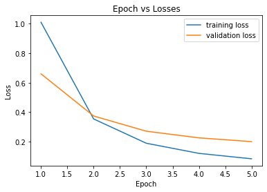

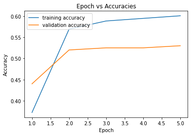

```python
# PARAMETERS:

# plot losses vs epoch
plt.plot([i+1 for i in range(max_epoch)], history['train_loss'], label='training loss')
plt.plot([i+1 for i in range(max_epoch)], history['vald_loss'], label='validation loss')
plt.xlabel('Epoch')
plt.ylabel('Loss')
plt.title('Epoch vs Losses')
plt.legend(loc='upper right')
plt.show()

# plot accuracies vs epoch
plt.plot([i+1 for i in range(max_epoch)], history['train_accuracy'], label='training accuracy')
plt.plot([i+1 for i in range(max_epoch)], history['vald_accuracy'], label='validation accuracy')
plt.xlabel('Epoch')
plt.ylabel('Accuracy')
plt.title('Epoch vs Accuracies')
plt.legend(loc='upper left')
plt.show()
```

### Test [4 points]

Following your analysis, report the confusion matrix for the best model you obtained (with the criteria you defined). Then, report the accuracy, precision, recall and $F_1$ score for the best model. In all of the metrics, use macro averaging.

```python
# TODO: Implement your evaluation script here, provide the confusion matrix and the requested metrics

model.load_state_dict(torch.load(PATH_TRANS_TRANSFER))

# evaluate on test set
# model = model.eval()

predictions = []

with torch.no_grad():
#   iterate over test batches
    for data in test_loader:
        images, labels = data
        images = images.permute(0, 3, 1, 2)
        #images, labels = images.cuda(), labels.cuda()
        outputs = model_cnn(images.float())
        _, predicted2 = torch.max(outputs.data, 1)
        predictions.extend(predicted2.tolist())

#   get confusion matrix
#   calculate accuracy
#   calculate precision
#   calculate recall
#   calculate F1 score
labelAndNames = {0: "Cloudy", 1: "Rain", 2: "Shine", 3: "Sunrise"}
cm = confusion_matrix(y_test,predictions)
# plot confusion matrix
plot_cm(cm, labelAndNames.values())
pscore = precision_score(y_test, predictions, average="macro")
rscore = recall_score(y_test, predictions, average="macro")
f1 = f1_score(y_test, predictions, average="macro")
print("Macro Precision:", pscore, "Macro Recall:", rscore,"Macro F1:" ,f1)
print("Accuracy", accuracy_score(y_test,predictions))
acc_per_class = cm.diagonal()/cm.sum(1)
print("Accuracies for each class:")
for i, acc in enumerate(acc_per_class):
    print(f'\tAccuracy for {labelAndNames[i]}'.ljust(30, ' '), acc)
```

[output not shown]

```
Macro Precision: 0.5358796296296297 Macro Recall: 0.6495944531658817 Macro F1: 0.5824711084501157
Accuracy 0.7022222222222222
Accuracies for each class:
	Accuracy for Cloudy           0.8076923076923077
	Accuracy for Rain             0.0
	Accuracy for Shine            0.8163265306122449
	Accuracy for Sunrise          0.9743589743589743
```

```python
#TRANSFER LEARNING SECOND TRIAL( PARAMETERS: BATCHSIZE:100, LEARNING RATE:5e-2)

max_epoch = 5
train_batch = 100
test_batch = 100
learning_rate = 5e-2
momentum = 0.5
weight_decay = 5e-04


model = models.resnet18(pretrained=True)
num_features = model.fc.in_features
model.fc = nn.Linear(in_features = num_features, out_features = 4)
# model.fc = replace its output layer with a linear layer (in_features, proper number according to your output classes)

optimizer = torch.optim.SGD(model.parameters(), lr = learning_rate, weight_decay = 5e-04) # you can play with momentum and weight_decay parameters as well

# define your loss function
criterion = nn.CrossEntropyLoss()

# start training
# for each epoch calculate validation performance
# save best model according to validation performance
PATH_TRANS_TRANSFER = "/content/drive/MyDrive/CS464_HW3/best_trans_sgd.pth"
min_vald_loss = np.inf
history = {'train_accuracy': [], 'vald_accuracy':[], 'train_loss': [], 'vald_loss': []}

for epoch in range(max_epoch):
    train_loss = 0.0
    train_correct = 0
    for i, data in enumerate(train_loader, 0):
        inputs, labels = data
        optimizer.zero_grad()
        input = inputs.permute(0, 3, 1, 2)
        outputs = model(input.float())
        preds = torch.argmax(outputs, dim=1)
        train_correct += torch.sum(preds==labels)
        loss = criterion(outputs, labels)
        loss.backward()
        optimizer.step()
        train_loss += loss.item()

#    Validation
    with torch.no_grad():
        vald_loss = 0.0
        vald_correct = 0
        for data in validation_loader:
            images, labels = data
            images, labels = images, labels
            images = images.permute(0, 3, 1, 2)
            outputs = model(images.float())
            preds = torch.argmax(outputs, dim=1)
            vald_correct += torch.sum(preds==labels)
            loss = criterion(outputs, labels)
            vald_loss += loss.item()
    print(f'Epoch {epoch+1}:\t\t train_loss: {(train_loss / len(train_loader)):.2f}\t\t train_accuracy: {(train_correct / (len(train_loader) * train_batch)):.2f}\t\t validation_loss: {(vald_loss / len(validation_loader)):.2f}\t\t validation_accuracy: {(vald_correct / (len(validation_loader) * test_batch)):.2f}')
    if (vald_loss / len(validation_loader)) < min_vald_loss:
        print(f'Saving new best Transfer Learning SGD with vald_loss: {(vald_loss / len(validation_loader)):.2f}')
        min_vald_loss = (vald_loss / len(validation_loader))
        torch.save(model.state_dict(), PATH_TRANS_TRANSFER)

    history['train_loss'].append(train_loss / len(train_loader))
    history['vald_loss'].append(vald_loss / len(validation_loader))
    history['train_accuracy'].append(train_correct / (len(train_loader) * train_batch))
    history['vald_accuracy'].append(vald_correct / (len(validation_loader) * test_batch))

print(f'Best validation loss: {min_vald_loss}')
```

```
Epoch 1:		 train_loss: 0.82		 train_accuracy: 0.44		 validation_loss: 0.31		 validation_accuracy: 0.51
Saving new best Transfer Learning SGD with vald_loss: 0.31
Epoch 2:		 train_loss: 0.07		 train_accuracy: 0.59		 validation_loss: 0.12		 validation_accuracy: 0.53
Saving new best Transfer Learning SGD with vald_loss: 0.12
Epoch 3:		 train_loss: 0.01		 train_accuracy: 0.61		 validation_loss: 0.13		 validation_accuracy: 0.53
Epoch 4:		 train_loss: 0.01		 train_accuracy: 0.61		 validation_loss: 0.14		 validation_accuracy: 0.54
Epoch 5:		 train_loss: 0.00		 train_accuracy: 0.61		 validation_loss: 0.14		 validation_accuracy: 0.54
Best validation loss: 0.11985982209444046
```

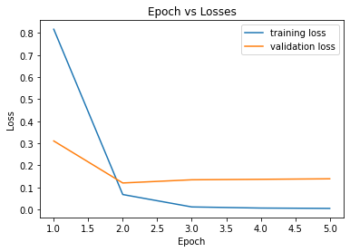

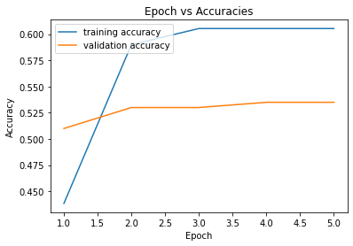

```python
# PARAMETERS:

# plot losses vs epoch
plt.plot([i+1 for i in range(max_epoch)], history['train_loss'], label='training loss')
plt.plot([i+1 for i in range(max_epoch)], history['vald_loss'], label='validation loss')
plt.xlabel('Epoch')
plt.ylabel('Loss')
plt.title('Epoch vs Losses')
plt.legend(loc='upper right')
plt.show()

# plot accuracies vs epoch
plt.plot([i+1 for i in range(max_epoch)], history['train_accuracy'], label='training accuracy')
plt.plot([i+1 for i in range(max_epoch)], history['vald_accuracy'], label='validation accuracy')
plt.xlabel('Epoch')
plt.ylabel('Accuracy')
plt.title('Epoch vs Accuracies')
plt.legend(loc='upper left')
plt.show()
```

```python
# TODO: Implement your evaluation script here, provide the confusion matrix and the requested metrics

model.load_state_dict(torch.load(PATH_TRANS_TRANSFER))

# evaluate on test set
# model = model.eval()

predictions = []

with torch.no_grad():
#   iterate over test batches
    for data in test_loader:
        images, labels = data
        images = images.permute(0, 3, 1, 2)
        #images, labels = images.cuda(), labels.cuda()
        outputs = model_cnn(images.float())
        _, predicted2 = torch.max(outputs.data, 1)
        predictions.extend(predicted2.tolist())

#   get confusion matrix
#   calculate accuracy
#   calculate precision
#   calculate recall
#   calculate F1 score
labelAndNames = {0: "Cloudy", 1: "Rain", 2: "Shine", 3: "Sunrise"}
cm = confusion_matrix(y_test,predictions)
# plot confusion matrix
plot_cm(cm, labelAndNames.values())
pscore = precision_score(y_test, predictions, average="macro")
rscore = recall_score(y_test, predictions, average="macro")
f1 = f1_score(y_test, predictions, average="macro")
print("Macro Precision:", pscore, "Macro Recall:", rscore,"Macro F1:" ,f1)
print("Accuracy", accuracy_score(y_test,predictions))
acc_per_class = cm.diagonal()/cm.sum(1)
print("Accuracies for each class:")
for i, acc in enumerate(acc_per_class):
    print(f'\tAccuracy for {labelAndNames[i]}'.ljust(30, ' '), acc)
```

[output not shown]

```
Macro Precision: 0.5358796296296297 Macro Recall: 0.6495944531658817 Macro F1: 0.5824711084501157
Accuracy 0.7022222222222222
Accuracies for each class:
	Accuracy for Cloudy           0.8076923076923077
	Accuracy for Rain             0.0
	Accuracy for Shine            0.8163265306122449
	Accuracy for Sunrise          0.9743589743589743
```

# References

[1] Ajayi, Gbeminiyi (2018), “Multi-class Weather Dataset for Image Classification”, Mendeley Data, V1, doi: 10.17632/4drtyfjtfy.1